# Assingmet4

LeeJoon Jeon

## 1. Predicting Delayed Flights

### 1. 다음의 순서로 data preprocessing을 진행하자.

```r
# 사용할 패키지 추가
setwd('/Users/Administrator/Desktop/데분')
```

```r
#데이터 읽기
fr <- read.csv("FlightRecords.csv")
str(fr)
```

```
## 'data.frame':    2201 obs. of  13 variables:
##  $ schedtime   : int  1455 1640 1245 1715 1039 840 1240 1645 1715 2120 ...
##  $ carrier     : chr  "OH" "DH" "DH" "DH" ...
##  $ deptime     : int  1455 1640 1245 1709 1035 839 1243 1644 1710 2129 ...
##  $ dest        : chr  "JFK" "JFK" "LGA" "LGA" ...
##  $ distance    : int  184 213 229 229 229 228 228 228 228 228 ...
##  $ date        : chr  "1/1/2004" "1/1/2004" "1/1/2004" "1/1/2004" ...
##  $ flightnumber: int  5935 6155 7208 7215 7792 7800 7806 7810 7812 7814 ...
##  $ origin      : chr  "BWI" "DCA" "IAD" "IAD" ...
##  $ weather     : int  0 0 0 0 0 0 0 0 0 0 ...
##  $ dayweek     : int  4 4 4 4 4 4 4 4 4 4 ...
##  $ daymonth    : int  1 1 1 1 1 1 1 1 1 1 ...
##  $ tailnu      : chr  "N940CA" "N405FJ" "N695BR" "N662BR" ...
##  $ delay       : chr  "ontime" "ontime" "ontime" "ontime" ...
```

```r
#출발시간 6시 이전 22시 이후 데이터 삭제
fr_pre <- subset(fr, fr$deptime >=600)
fr_pre <- subset(fr_pre, fr_pre$deptime <2200)
str(fr_pre)
```

```
## 'data.frame':    2159 obs. of  13 variables:
##  $ schedtime   : int  1455 1640 1245 1715 1039 840 1240 1645 1715 2120 ...
##  $ carrier     : chr  "OH" "DH" "DH" "DH" ...
##  $ deptime     : int  1455 1640 1245 1709 1035 839 1243 1644 1710 2129 ...
##  $ dest        : chr  "JFK" "JFK" "LGA" "LGA" ...
##  $ distance    : int  184 213 229 229 229 228 228 228 228 228 ...
##  $ date        : chr  "1/1/2004" "1/1/2004" "1/1/2004" "1/1/2004" ...
##  $ flightnumber: int  5935 6155 7208 7215 7792 7800 7806 7810 7812 7814 ...
##  $ origin      : chr  "BWI" "DCA" "IAD" "IAD" ...
##  $ weather     : int  0 0 0 0 0 0 0 0 0 0 ...
##  $ dayweek     : int  4 4 4 4 4 4 4 4 4 4 ...
##  $ daymonth    : int  1 1 1 1 1 1 1 1 1 1 ...
##  $ tailnu      : chr  "N940CA" "N405FJ" "N695BR" "N662BR" ...
##  $ delay       : chr  "ontime" "ontime" "ontime" "ontime" ...
```

```r
#출발시각을 범주형 변수로 변환
fr_pre$deptime <- floor(fr_pre$deptime/100)
str(fr_pre)
```

```
## 'data.frame':    2159 obs. of  13 variables:
##  $ schedtime   : int  1455 1640 1245 1715 1039 840 1240 1645 1715 2120 ...
##  $ carrier     : chr  "OH" "DH" "DH" "DH" ...
##  $ deptime     : num  14 16 12 17 10 8 12 16 17 21 ...
##  $ dest        : chr  "JFK" "JFK" "LGA" "LGA" ...
##  $ distance    : int  184 213 229 229 229 228 228 228 228 228 ...
##  $ date        : chr  "1/1/2004" "1/1/2004" "1/1/2004" "1/1/2004" ...
##  $ flightnumber: int  5935 6155 7208 7215 7792 7800 7806 7810 7812 7814 ...
##  $ origin      : chr  "BWI" "DCA" "IAD" "IAD" ...
##  $ weather     : int  0 0 0 0 0 0 0 0 0 0 ...
##  $ dayweek     : int  4 4 4 4 4 4 4 4 4 4 ...
##  $ daymonth    : int  1 1 1 1 1 1 1 1 1 1 ...
##  $ tailnu      : chr  "N940CA" "N405FJ" "N695BR" "N662BR" ...
##  $ delay       : chr  "ontime" "ontime" "ontime" "ontime" ...
```

```r
fr_pre$deptime <- factor(fr_pre$deptime)
str(fr_pre)
```

```
## 'data.frame':    2159 obs. of  13 variables:
##  $ schedtime   : int  1455 1640 1245 1715 1039 840 1240 1645 1715 2120 ...
##  $ carrier     : chr  "OH" "DH" "DH" "DH" ...
##  $ deptime     : Factor w/ 16 levels "6","7","8","9",..: 9 11 7 12 5 3 7 11 12 16 ...
##  $ dest        : chr  "JFK" "JFK" "LGA" "LGA" ...
##  $ distance    : int  184 213 229 229 229 228 228 228 228 228 ...
##  $ date        : chr  "1/1/2004" "1/1/2004" "1/1/2004" "1/1/2004" ...
##  $ flightnumber: int  5935 6155 7208 7215 7792 7800 7806 7810 7812 7814 ...
##  $ origin      : chr  "BWI" "DCA" "IAD" "IAD" ...
##  $ weather     : int  0 0 0 0 0 0 0 0 0 0 ...
##  $ dayweek     : int  4 4 4 4 4 4 4 4 4 4 ...
##  $ daymonth    : int  1 1 1 1 1 1 1 1 1 1 ...
##  $ tailnu      : chr  "N940CA" "N405FJ" "N695BR" "N662BR" ...
##  $ delay       : chr  "ontime" "ontime" "ontime" "ontime" ...
```

```r
#dayweek, weather factor로 변환
fr_pre$weather <- factor(fr_pre$weathe)
fr_pre$dayweek <- factor(fr_pre$dayweek)
str(fr_pre)
```

```
## 'data.frame':    2159 obs. of  13 variables:
##  $ schedtime   : int  1455 1640 1245 1715 1039 840 1240 1645 1715 2120 ...
##  $ carrier     : chr  "OH" "DH" "DH" "DH" ...
##  $ deptime     : Factor w/ 16 levels "6","7","8","9",..: 9 11 7 12 5 3 7 11 12 16 ...
##  $ dest        : chr  "JFK" "JFK" "LGA" "LGA" ...
##  $ distance    : int  184 213 229 229 229 228 228 228 228 228 ...
##  $ date        : chr  "1/1/2004" "1/1/2004" "1/1/2004" "1/1/2004" ...
##  $ flightnumber: int  5935 6155 7208 7215 7792 7800 7806 7810 7812 7814 ...
##  $ origin      : chr  "BWI" "DCA" "IAD" "IAD" ...
##  $ weather     : Factor w/ 2 levels "0","1": 1 1 1 1 1 1 1 1 1 1 ...
##  $ dayweek     : Factor w/ 7 levels "1","2","3","4",..: 4 4 4 4 4 4 4 4 4 4 ...
##  $ daymonth    : int  1 1 1 1 1 1 1 1 1 1 ...
##  $ tailnu      : chr  "N940CA" "N405FJ" "N695BR" "N662BR" ...
##  $ delay       : chr  "ontime" "ontime" "ontime" "ontime" ...
```

```r
#delay변수가 가지는 level의 순서를 "ontime","delay"순으로 변환
fr_pre$delay <- factor(fr_pre$delay, levels = c("ontime", "delayed"))
str(fr_pre)
```

```
## 'data.frame':    2159 obs. of  13 variables:
##  $ schedtime   : int  1455 1640 1245 1715 1039 840 1240 1645 1715 2120 ...
##  $ carrier     : chr  "OH" "DH" "DH" "DH" ...
##  $ deptime     : Factor w/ 16 levels "6","7","8","9",..: 9 11 7 12 5 3 7 11 12 16 ...
##  $ dest        : chr  "JFK" "JFK" "LGA" "LGA" ...
##  $ distance    : int  184 213 229 229 229 228 228 228 228 228 ...
##  $ date        : chr  "1/1/2004" "1/1/2004" "1/1/2004" "1/1/2004" ...
##  $ flightnumber: int  5935 6155 7208 7215 7792 7800 7806 7810 7812 7814 ...
##  $ origin      : chr  "BWI" "DCA" "IAD" "IAD" ...
##  $ weather     : Factor w/ 2 levels "0","1": 1 1 1 1 1 1 1 1 1 1 ...
##  $ dayweek     : Factor w/ 7 levels "1","2","3","4",..: 4 4 4 4 4 4 4 4 4 4 ...
##  $ daymonth    : int  1 1 1 1 1 1 1 1 1 1 ...
##  $ tailnu      : chr  "N940CA" "N405FJ" "N695BR" "N662BR" ...
##  $ delay       : Factor w/ 2 levels "ontime","delayed": 1 1 1 1 1 1 1 1 1 1 ...
```

### 2. 요일 별 연착비율, 출발 시간대 별 연착 비율, 출발 공항 별 연착비율, 도착 공항 별 연착 비율, 항공사 별 연착비율, 날씨 별 연착 비율을 각각 그래프로 시각화해보자. 어떤 특성을 관찰할 수 있는가?

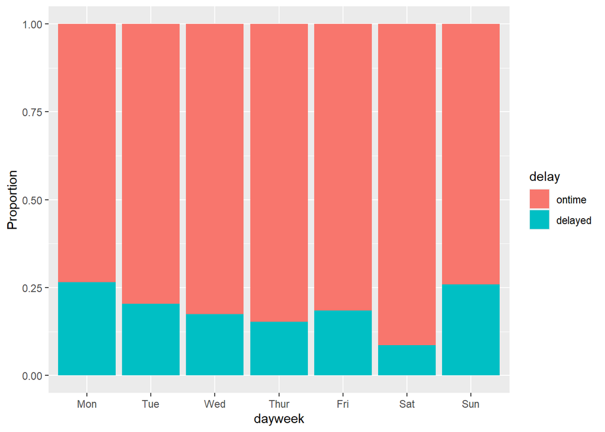

```r
library(ggplot2)
#요일별 연착비율
ggplot(fr_pre, aes(x=factor(dayweek,levels=c("1","2","3","4","5","6","7"), labels=c("Mon","Tue","Wed","Thur","Fri","Sat","Sun")),fill=delay)) + geom_bar(position="fill") + labs(x="dayweek",y="Proportion")
```

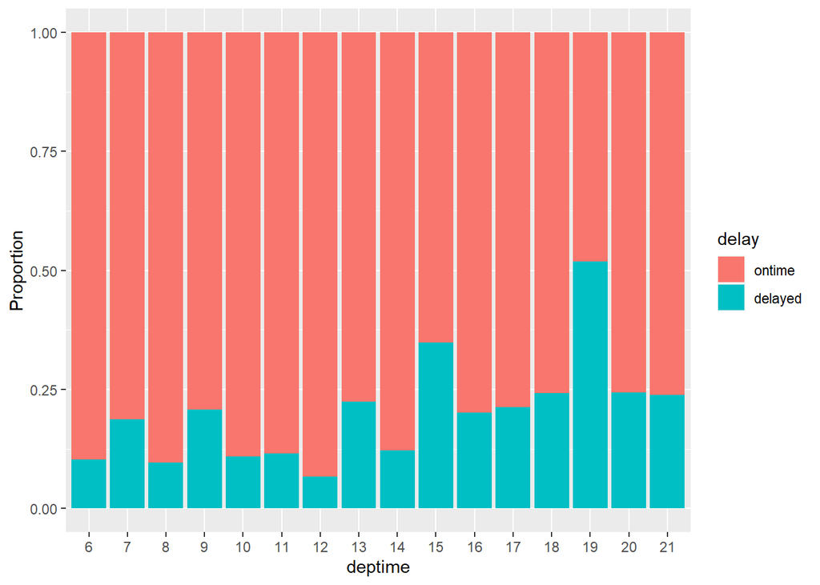

```r
#출발 시간대 별 연착 비율
ggplot(fr_pre, aes(x=deptime, fill=delay)) + geom_bar(position="fill") + labs(y="Proportion")
```

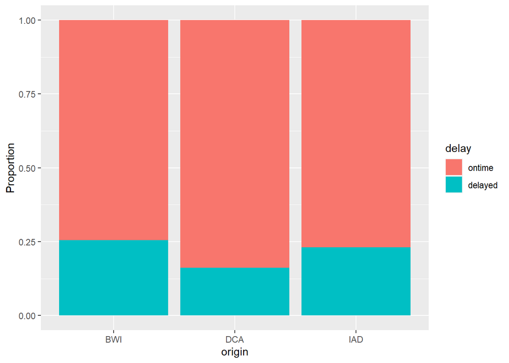

```r
#출발 공항 별 연착 비율
ggplot(fr_pre, aes(x=origin, fill= delay)) + geom_bar(position="fill") + labs(y="Proportion")
```

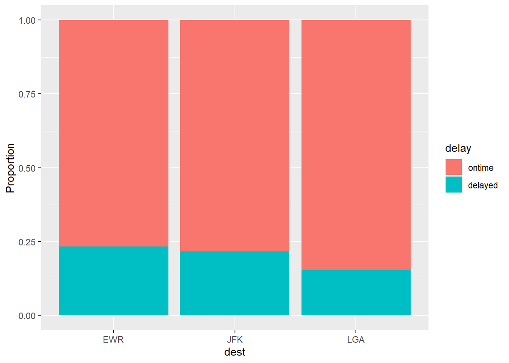

```r
#도착 공항 별 연착 비율
ggplot(fr_pre, aes(x=dest, fill=delay)) + geom_bar(position="fill") + labs(y="Proportion")
```

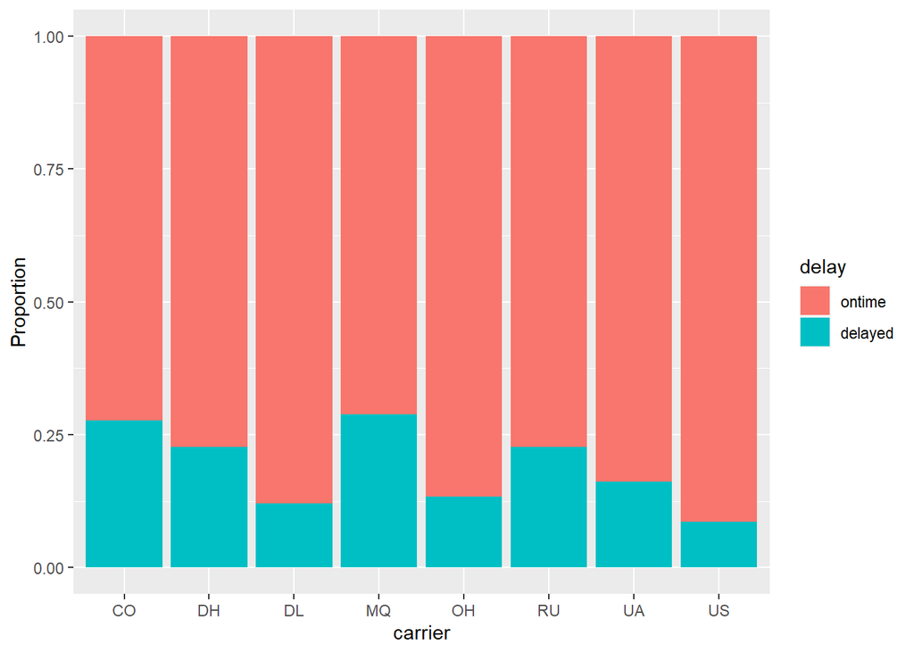

```r
#항공사 별 연착 비율
ggplot(fr_pre, aes(x=carrier,fill=delay)) + geom_bar(position="fill") +labs(y="Proportion")
```

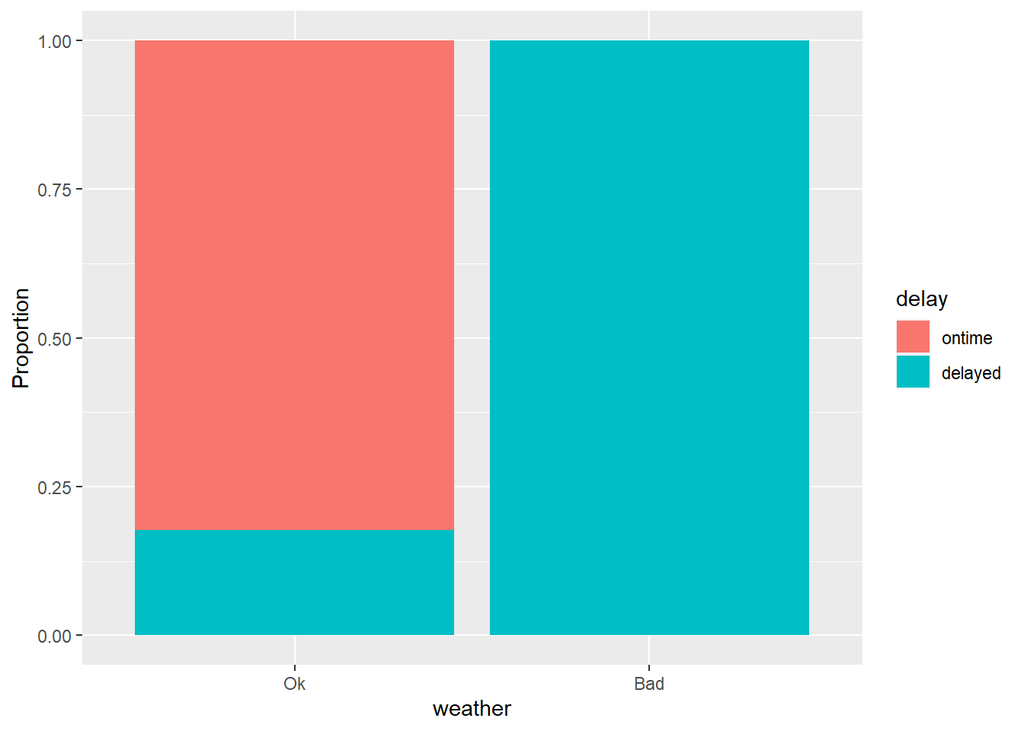

```r
#날씨 별 연착 비율
ggplot(fr_pre, aes(x=factor(weather,levels=c("0","1"), labels=c("Ok","Bad")), fill=delay)) + geom_bar(position="fill") + labs(x="weather",y="Proportion")
```

#### 2)출발 시간대별 연착 비율을 보면 일반적으로 출발시간이 늦을수록 연착되는 비율이 증가하는 모습이다. 출발시간 19시대인 비행기에서 연착비율이 가장 높으며 12시대에 연착비율이 가장 낮다.

#### 3)출발 공항별 연착 비율을 보면 출발 공항인 DCA,IAD,BWI 세 곳 모두 큰 차이는 보이지 않는다. 굳이 비교를 하자면 BWI에서 연착비율이 0.25를 넘고 가장 큰 비율을 가지며 DCA에서 가장 낮은 비율을 가진다.

#### 4) 도착 공항별 연착 비율을 보면 도착 공항인 EWR,JFK,LGA 세 곳 모두 연착 비율이 0.25보다 낮은 값을 가진다. 세 곳 모두 큰 차이는 없으며 EWR이 근소한 차이로 가장 높은 연착비율을 가지고 LGA가 가장 낮은 연착비율을 가진다.

#### 5) 항공사별 연착 비율을 보면 CO,MQ항공사가 0.25를 넘는 연착비율을 보이고 있다. 그 외에 나머지 항공사는 0.25보다 낮은 연착비율을 보이며 특히 DL,OH,US항공사는 0.1대의 연착 비율을 가지고 있다. MQ항공사가 가장 높은 연착비율을 가지며 US항공사가 가장 낮은 연착비율을 가진다.

#### 6)날씨별 연착 비율을 보면 날씨가 좋지 않은 날은 모두 비행기가 연착되는 것을 볼 수 있다. 날씨가 좋을 때는 0.25보다 낮은 비율로 비행기가 연착된다.

### 3. 7개의 모든 변수들 간의 상관관계를 시각화해보자. 어떤 특성을 관찰할 수 있는가?

```r
#필요없는 변수 제거
fr_pre <- subset(fr_pre, select = -c(schedtime, distance, date, flightnumber, daymonth, tailnu))
str(fr_pre)
```

```
## 'data.frame':    2159 obs. of  7 variables:
##  $ carrier: chr  "OH" "DH" "DH" "DH" ...
##  $ deptime: Factor w/ 16 levels "6","7","8","9",..: 9 11 7 12 5 3 7 11 12 16 ...
##  $ dest   : chr  "JFK" "JFK" "LGA" "LGA" ...
##  $ origin : chr  "BWI" "DCA" "IAD" "IAD" ...
##  $ weather: Factor w/ 2 levels "0","1": 1 1 1 1 1 1 1 1 1 1 ...
##  $ dayweek: Factor w/ 7 levels "1","2","3","4",..: 4 4 4 4 4 4 4 4 4 4 ...
##  $ delay  : Factor w/ 2 levels "ontime","delayed": 1 1 1 1 1 1 1 1 1 1 ...
```

```r
library(psych)
```

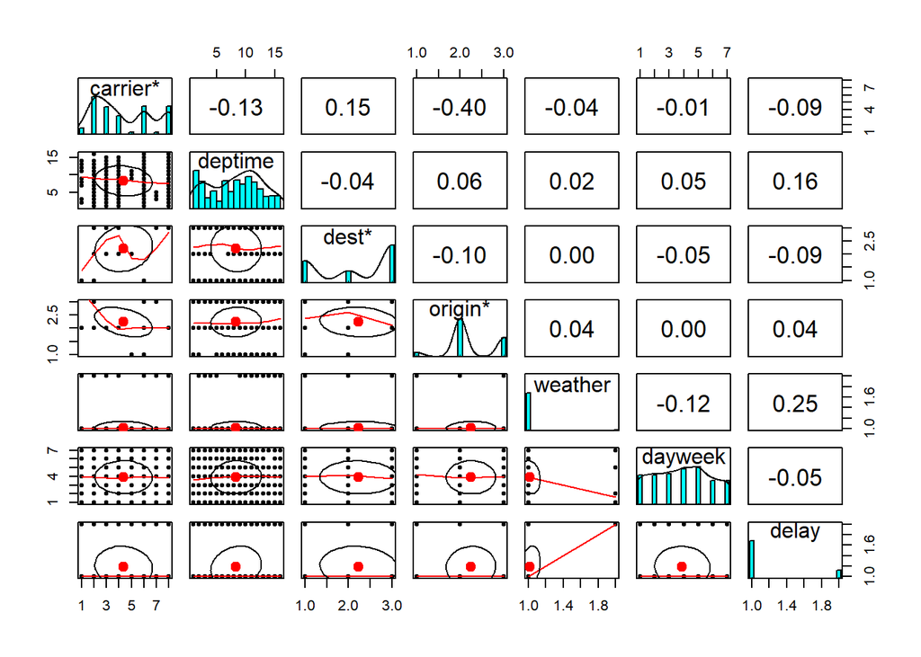

```r
#상관관계
pairs.panels(fr_pre)
```

```r
table(fr_pre$delay)
```

```
##
##  ontime delayed
##    1750     409
```

#### 전체적으로 보면 강한 상관관계를 가지고 있는 변수가 없다. 이 중 가장 높은 상관관계를 가지는 변수는 carrier와 origin이며 -0.4로 음의 상관관계를 가진다. dest와 weather, origin과 dayweek 아예 상관관계가 존재하지 않는다고 볼 수 있다.

### 4. 데이터셋을 70:30 비율로 training set과 test set으로 분할하자. 이때 stratified sampling을 활용하여 두 set에서 delay 변수의 분포가 크게 차이가 없도록 분할하자

```r
#stratified smapling 활용하여 test set, training set 분할.
library(rsample)
set.seed(123)
tr <- initial_split(fr_pre, prop = 0.7, strata = "delay")
train <- training(tr)
test <- testing(tr)

table(train$delay)
```

```
##
##  ontime delayed
##    1225     287
```

```r
table(test$delay)
```

```
##
##  ontime delayed
##     525     122
```

#### training set 에는 ontime 1225개, delayed 287개, test set에는 ontime 525개, delayed 122개 분류되었다.

### 5. 데이터시각화로부터 weather 변수가 “Bad” 인 경우에는 항상 항공기가 연착되는 것을 관찰할 수 있다. 따라서 weather가 Bad이면 항공기가 연착되고, weather가 OK일 경우 항공기가 연착되지 않는 것으로 예측하는 단순한 모델을 baseline model이라 하자. Test set에 대해 baseline model을 적용했을 때 confusion matrix를 계산해 보세요.

```r
#baseline model
library(caret)
pred_base <- factor(sign(test$weather=="1"), levels=c(0,1), labels = c("ontime","delayed"))
confusionMatrix(pred_base, test$delay ,positive="delayed")
```

```
## Confusion Matrix and Statistics
##
##           Reference
## Prediction ontime delayed
##    ontime     525     111
##    delayed      0      11
##
##                Accuracy : 0.8284
##                  95% CI : (0.7971, 0.8567)
##     No Information Rate : 0.8114
##     P-Value [Acc > NIR] : 0.1453
##
##                   Kappa : 0.1385
##
##  Mcnemar's Test P-Value : <2e-16
##
##             Sensitivity : 0.09016
##             Specificity : 1.00000
##          Pos Pred Value : 1.00000
##          Neg Pred Value : 0.82547
##              Prevalence : 0.18856
##          Detection Rate : 0.01700
##    Detection Prevalence : 0.01700
##       Balanced Accuracy : 0.54508
##
##        'Positive' Class : delayed
##
```

#### basline model의 Accuracy: 0.8284, Sensitivity: 0.09016, Specificity: 1이다. 특히 basline model에서 실제 ontime일 때 delayed로 예측한 경우가 없다는 것이 눈에 가장 띄었다. 반면에 실제 delayed일 때 ontime이라고 예측한 경우는 111건이나 있었다.

### 6. Training set을 대상으로, 연착여부(delay)를 나머지 모든 변수를 사용하여 예측하기 위한 logistic regression model을 수립해보자.

```r
#6-1logistic regression model
model <- glm(delay~., data=train, family="binomial")
summary(model)
```

```
##
## Call:
## glm(formula = delay ~ ., family = "binomial", data = train)
##
## Deviance Residuals:
##     Min       1Q   Median       3Q      Max
## -1.7062  -0.6330  -0.4682  -0.2536   2.7698
##
## Coefficients:
##              Estimate Std. Error z value Pr(>|z|)
## (Intercept)  -0.22195    0.61263  -0.362 0.717130
## carrierDH    -0.92739    0.55339  -1.676 0.093769 .
## carrierDL    -1.47989    0.51558  -2.870 0.004101 **
## carrierMQ    -0.20680    0.48784  -0.424 0.671631
## carrierOH    -1.42050    0.85996  -1.652 0.098570 .
## carrierRU    -0.77349    0.42382  -1.825 0.067999 .
## carrierUA    -1.77673    1.02612  -1.732 0.083360 .
## carrierUS    -1.81208    0.52262  -3.467 0.000526 ***
## deptime7      0.30868    0.49279   0.626 0.531057
## deptime8      0.01138    0.44921   0.025 0.979790
## deptime9      1.49375    0.50407   2.963 0.003043 **
## deptime10    -0.17018    0.49551  -0.343 0.731259
## deptime11    -0.02284    0.81193  -0.028 0.977563
## deptime12    -0.46717    0.45974  -1.016 0.309555
## deptime13     1.09505    0.40969   2.673 0.007520 **
## deptime14    -0.08903    0.42308  -0.210 0.833335
## deptime15     1.68475    0.38342   4.394 1.11e-05 ***
## deptime16     0.88760    0.38638   2.297 0.021607 *
## deptime17     0.87711    0.37890   2.315 0.020621 *
## deptime18     1.14860    0.41212   2.787 0.005319 **
## deptime19     2.57044    0.44809   5.736 9.67e-09 ***
## deptime20     1.38581    0.46820   2.960 0.003078 **
## deptime21     0.71707    0.44908   1.597 0.110322
## destJFK      -0.15592    0.32761  -0.476 0.634133
## destLGA       0.28194    0.33636   0.838 0.401917
## originDCA    -1.23374    0.39269  -3.142 0.001679 **
## originIAD    -0.32671    0.37791  -0.865 0.387303
## weather1     17.56718  500.86204   0.035 0.972021
## dayweek2     -0.34612    0.26596  -1.301 0.193125
## dayweek3     -0.49452    0.26130  -1.893 0.058421 .
## dayweek4     -0.53836    0.25922  -2.077 0.037817 *
## dayweek5     -0.24197    0.24498  -0.988 0.323307
## dayweek6     -1.17170    0.33498  -3.498 0.000469 ***
## dayweek7     -0.11203    0.27348  -0.410 0.682068
## ---
## Signif. codes:  0 '***' 0.001 '**' 0.01 '*' 0.05 '.' 0.1 ' ' 1
##
## (Dispersion parameter for binomial family taken to be 1)
##
##     Null deviance: 1469.5  on 1511  degrees of freedom
## Residual deviance: 1216.4  on 1478  degrees of freedom
## AIC: 1284.4
##
## Number of Fisher Scoring iterations: 15
```

```r
#6-2날씨에 문제가 없는 금요일 15시에 IAD에서 출발하여 JFK로 도착한 Delta 항공기가 연착될 확률
weather <- c("0")
dayweek <- c("5")
deptime <- c("15")
origin <- c("IAD")
dest <- c("JFK")
carrier <- c("DL")
cc <- data.frame(weather, dayweek, deptime, origin, dest, carrier)
str(cc)
```

```
## 'data.frame':    1 obs. of  6 variables:
##  $ weather: chr "0"
##  $ dayweek: chr "5"
##  $ deptime: chr "15"
##  $ origin : chr "IAD"
##  $ dest   : chr "JFK"
##  $ carrier: chr "DL"
```

```r
predict(model,cc,type="response")
```

```
##         1
## 0.3226365
```

```r
#6-3
#Threshold k=0.2
p <- predict(model, test, type="response")
O_or_B <- ifelse(p>0.2, "delayed","ontime")
p_class <- factor(O_or_B, levels = levels(test$delay))
confusionMatrix(p_class, test$delay, positive="delayed")
```

```
## Confusion Matrix and Statistics
##
##           Reference
## Prediction ontime delayed
##    ontime     382      45
##    delayed    143      77
##
##                Accuracy : 0.7094
##                  95% CI : (0.6728, 0.7442)
##     No Information Rate : 0.8114
##     P-Value [Acc > NIR] : 1
##
##                   Kappa : 0.2742
##
##  Mcnemar's Test P-Value : 1.5e-12
##
##             Sensitivity : 0.6311
##             Specificity : 0.7276
##          Pos Pred Value : 0.3500
##          Neg Pred Value : 0.8946
##              Prevalence : 0.1886
##          Detection Rate : 0.1190
##    Detection Prevalence : 0.3400
##       Balanced Accuracy : 0.6794
##
##        'Positive' Class : delayed
##
```

```r
#Threshold k=0.3
O_or_B <- ifelse(p>0.3,"delayed","ontime")
p_class <- factor(O_or_B, levels = levels(test$delay))
confusionMatrix(p_class, test$delay, positive="delayed")
```

```
## Confusion Matrix and Statistics
##
##           Reference
## Prediction ontime delayed
##    ontime     452      65
##    delayed     73      57
##
##                Accuracy : 0.7867
##                  95% CI : (0.7531, 0.8177)
##     No Information Rate : 0.8114
##     P-Value [Acc > NIR] : 0.9496
##
##                   Kappa : 0.3201
##
##  Mcnemar's Test P-Value : 0.5513
##
##             Sensitivity : 0.4672
##             Specificity : 0.8610
##          Pos Pred Value : 0.4385
##          Neg Pred Value : 0.8743
##              Prevalence : 0.1886
##          Detection Rate : 0.0881
##    Detection Prevalence : 0.2009
##       Balanced Accuracy : 0.6641
##
##        'Positive' Class : delayed
##
```

```r
#Threshold k=0.5
O_or_B <- ifelse(p>0.5,"delayed","ontime")
p_class <- factor(O_or_B, levels = levels(test$delay))
confusionMatrix(p_class, test$delay, positive="delayed")
```

```
## Confusion Matrix and Statistics
##
##           Reference
## Prediction ontime delayed
##    ontime     519      92
##    delayed      6      30
##
##                Accuracy : 0.8485
##                  95% CI : (0.8186, 0.8753)
##     No Information Rate : 0.8114
##     P-Value [Acc > NIR] : 0.007869
##
##                   Kappa : 0.3214
##
##  Mcnemar's Test P-Value : < 2.2e-16
##
##             Sensitivity : 0.24590
##             Specificity : 0.98857
##          Pos Pred Value : 0.83333
##          Neg Pred Value : 0.84943
##              Prevalence : 0.18856
##          Detection Rate : 0.04637
##    Detection Prevalence : 0.05564
##       Balanced Accuracy : 0.61724
##
##        'Positive' Class : delayed
##
```

```r
#Threshold k=0.7
O_or_B <- ifelse(p>0.7,"delayed","ontime")
p_class <- factor(O_or_B, levels = levels(test$delay))
confusionMatrix(p_class, test$delay, positive="delayed")
```

```
## Confusion Matrix and Statistics
##
##           Reference
## Prediction ontime delayed
##    ontime     525     105
##    delayed      0      17
##
##                Accuracy : 0.8377
##                  95% CI : (0.807, 0.8653)
##     No Information Rate : 0.8114
##     P-Value [Acc > NIR] : 0.04666
##
##                   Kappa : 0.2081
##
##  Mcnemar's Test P-Value : < 2e-16
##
##             Sensitivity : 0.13934
##             Specificity : 1.00000
##          Pos Pred Value : 1.00000
##          Neg Pred Value : 0.83333
##              Prevalence : 0.18856
##          Detection Rate : 0.02628
##    Detection Prevalence : 0.02628
##       Balanced Accuracy : 0.56967
##
##        'Positive' Class : delayed
##
```

#### 6-1. deptime19의 regression coefficient에 대한 추정값은 2.57044이다. 다른 deptime변수들과 비교했을때 가장 큰 값으로 19시시간대의 비행기가 연착비율이 높을 것이다.

#### 6-2. 문제가 없는 금요일 15시에 IAD에서 출발하여 JFK로 도착한 Delta 항공기가 연착될 확률은 0.3226365이다.

#### 6-3. Threshold가 커질수록 Sensitiviy는 감소했고 Specificity는 증가했다. Threshold가 0.5일 때 최대 Accuracy를 가졌다.

| Threshold | Accuracy | Sensitivity | Specificity |
| --- | --- | --- | --- |
| k=0.2 | 0.7094 | 0.6311 | 0.7276 |
| k=0.3 | 0.7867 | 0.4672 | 0.8610 |
| k=0.5 | 0.8485 | 0.24590 | 0.98857 |
| k=0.7 | 0.8377 | 0.13934 | 1.00000 |

#### 6-4. Basline model의 Accuracy가 0.8284로 Threshold k=0.5보다 작은 logistic regression model들의 Accuracy보다 높고 Threshold k=0.5이상의 logistic regression model의 Accuracy보다는 낮다. 간단한 Baseline model의 성능이 크게 나쁘다고 볼 수는 없지만 logistic regression model은 Threshold 값에 따라 Accuracy가 향상된다.

| Model | Accuracy | Sensitivity | Specificity |
| --- | --- | --- | --- |
| Baseline model | 0.8284 | 0.09016 | 1.00000 |
| Threshold(k=0.2) | 0.7094 | 0.6311 | 0.7276 |
| Threshold(k=0.3) | 0.7867 | 0.4672 | 0.8610 |
| Threshold(k=0.5) | 0.8485 | 0.24590 | 0.98857 |
| Threshold(k=0.7) | 0.8377 | 0.13934 | 1.00000 |

### 7. Training set을 대상으로, step() 함수를 활용한 backward stepwise selection을 적용하여 logistic regression model을 수립해보자.

```r
#backward stepwise selection
model_step <- step(model, direction="backward")
```

```
## Start:  AIC=1284.41
## delay ~ carrier + deptime + dest + origin + weather + dayweek
##
##           Df Deviance    AIC
## - dest     2   1219.4 1283.4
## <none>         1216.4 1284.4
## - dayweek  6   1233.6 1289.6
## - origin   2   1228.8 1292.8
## - carrier  7   1256.0 1310.0
## - weather  1   1267.0 1333.0
## - deptime 15   1320.7 1358.7
##
## Step:  AIC=1283.38
## delay ~ carrier + deptime + origin + weather + dayweek
##
##           Df Deviance    AIC
## <none>         1219.4 1283.4
## - dayweek  6   1237.8 1289.8
## - origin   2   1231.8 1291.8
## - carrier  7   1259.1 1309.1
## - weather  1   1270.3 1332.3
## - deptime 15   1321.2 1355.2
```

```r
coef(model_step)
```

```
## (Intercept)   carrierDH   carrierDL   carrierMQ   carrierOH   carrierRU
## -0.20812675 -0.92955698 -1.22062246 -0.02136833 -1.50385323 -0.76453070
##   carrierUA   carrierUS    deptime7    deptime8    deptime9   deptime10
## -1.49918869 -1.52771547  0.31761353 -0.04104224  1.44790808 -0.10468396
##   deptime11   deptime12   deptime13   deptime14   deptime15   deptime16
## -0.01973178 -0.46354036  1.09783364 -0.13707276  1.57842541  0.80039535
##   deptime17   deptime18   deptime19   deptime20   deptime21   originDCA
##  0.85844204  1.04964764  2.56519761  1.34883491  0.69412744 -1.20663476
##   originIAD    weather1    dayweek2    dayweek3    dayweek4    dayweek5
## -0.27426272 17.57839281 -0.36546869 -0.50192067 -0.54372374 -0.25159366
##    dayweek6    dayweek7
## -1.21327174 -0.11098357
```

```r
#Threshold k=0.5
prob_step <- predict(model_step,test, type="response")
pred_step <- rep("ontime",647)
pred_step[prob_step>0.5] <- "delayed"
confusionMatrix(factor(pred_step),test$delay, positive="delayed")
```

```
## Confusion Matrix and Statistics
##
##           Reference
## Prediction ontime delayed
##    ontime     515      90
##    delayed     10      32
##
##                Accuracy : 0.8454
##                  95% CI : (0.8152, 0.8724)
##     No Information Rate : 0.8114
##     P-Value [Acc > NIR] : 0.01379
##
##                   Kappa : 0.3251
##
##  Mcnemar's Test P-Value : 2.789e-15
##
##             Sensitivity : 0.26230
##             Specificity : 0.98095
##          Pos Pred Value : 0.76190
##          Neg Pred Value : 0.85124
##              Prevalence : 0.18856
##          Detection Rate : 0.04946
##    Detection Prevalence : 0.06491
##       Balanced Accuracy : 0.62162
##
##        'Positive' Class : delayed
##
```

#### 7-1. carrierDH, carrierDL, carrierMQ, carrierOH, carrierRU, carrierUA, carrierUS, deptime7, deptime8, deptime9, deptime10, deptime11, deptime12, deptime13, deptime14, deptime15, deptime16, deptime17, deptime18, deptime19, deptime20, deptime21, originDCA, originIAD, weather1, dayweek2, dayweek3, dayweek4, dayweek5, dayweek6, dayweek7로 변수는 31개이다.

#### 7-2. Accuracy: 0.8454, Sensitivity: 0.2623, Speicificity: 0.98095이다. ontime으로 예측한 것 중에 515개가 맞았고 90개가 실제 delayed로 틀렸다. delayed로 예측한 것 중에 32개가 맞았고 10개가 실제 ontime으로 틀렸다.

### 8. Training set을 대상으로 Lasso regression을 적용하여 logistic regression model을 수립해보자. CV의 결과 바탕으로 모델에 포함되는 feature의 수와 예측정확도를 모두 고려했을 때 적합한 모델을 선택하자.

```r
library(glmnet)
```

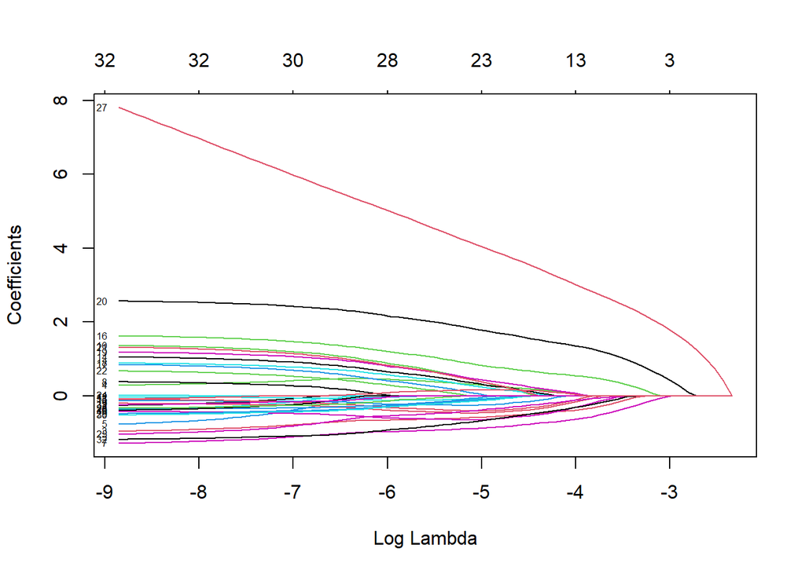

```r
#feature matrix 생성
trainX <- model.matrix(delay~., data=train)[,-7]
trainY <- train$delay

#lasso regression
set.seed(23)
lasso_model <- glmnet(x=trainX, y=trainY, alpha=1, family="binomial")
plot(lasso_model, xvar="lambda", label=TRUE)
```

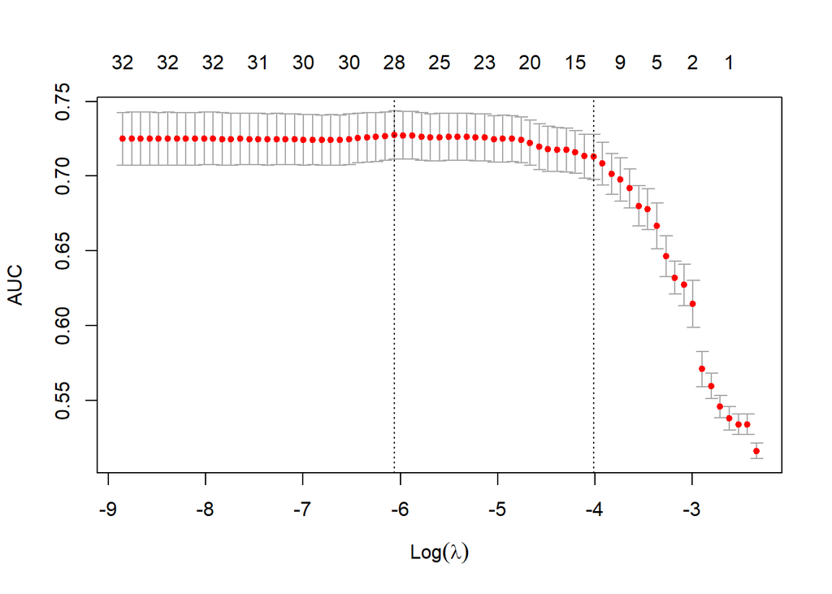

```r
#cross validaion
set.seed(23)
cv_lasso <- cv.glmnet(x=trainX, y=trainY, alpha=1, family="binomial",type.measure = "auc",nfold=10)
plot(cv_lasso)
```

```r
#AUC값이 크고 변수의 개수가 적다고 판단되는 곳은 변수가 15개일 때


#cv에 사용된 lambda
cv_lasso$lambda
```

```
##  [1] 0.0961512918 0.0876094760 0.0798264916 0.0727349261 0.0662733558
##  [6] 0.0603858135 0.0550213043 0.0501333632 0.0456796534 0.0416215989
## [11] 0.0379240508 0.0345549826 0.0314852132 0.0286881537 0.0261395772
## [16] 0.0238174092 0.0217015362 0.0197736315 0.0180169966 0.0164164163
## [21] 0.0149580271 0.0136291972 0.0124184169 0.0113151990 0.0103099879
## [26] 0.0093940770 0.0085595331 0.0077991277 0.0071062747 0.0064749729
## [31] 0.0058997541 0.0053756362 0.0048980795 0.0044629476 0.0040664717
## [36] 0.0037052175 0.0033760562 0.0030761367 0.0028028612 0.0025538627
## [41] 0.0023269846 0.0021202617 0.0019319035 0.0017602785 0.0016039002
## [46] 0.0014614141 0.0013315861 0.0012132917 0.0011055062 0.0010072961
## [51] 0.0009178107 0.0008362749 0.0007619825 0.0006942901 0.0006326113
## [56] 0.0005764119 0.0005252050 0.0004785472 0.0004360344 0.0003972983
## [61] 0.0003620034 0.0003298441 0.0003005416 0.0002738423 0.0002495149
## [66] 0.0002273487 0.0002071517 0.0001887489 0.0001719810 0.0001567026
## [71] 0.0001427816
```

```r
#nonzero 변수의 수
cv_lasso$nzero
```

```
##  s0  s1  s2  s3  s4  s5  s6  s7  s8  s9 s10 s11 s12 s13 s14 s15 s16 s17 s18 s19
##   0   1   1   1   1   2   2   2   3   4   4   5   7   8   8   9  10  13  13  13
## s20 s21 s22 s23 s24 s25 s26 s27 s28 s29 s30 s31 s32 s33 s34 s35 s36 s37 s38 s39
##  15  16  17  19  19  20  21  21  23  23  23  25  25  25  25  25  25  26  27  28
## s40 s41 s42 s43 s44 s45 s46 s47 s48 s49 s50 s51 s52 s53 s54 s55 s56 s57 s58 s59
##  28  28  29  30  30  30  30  30  30  30  30  30  30  30  31  31  31  31  31  32
## s60 s61 s62 s63 s64 s65 s66 s67 s68 s69 s70
##  32  32  32  32  32  32  32  32  32  32  32
```

```r
#performace measure
cv_lasso$cvm
```

```
##  [1] 0.5163092 0.5340976 0.5340976 0.5381845 0.5460032 0.5597317 0.5709630
##  [8] 0.6146992 0.6273148 0.6320872 0.6465781 0.6665771 0.6779075 0.6800682
## [15] 0.6917043 0.6976953 0.7012481 0.7083142 0.7129420 0.7132120 0.7160271
## [22] 0.7173456 0.7177159 0.7181408 0.7197471 0.7222409 0.7240860 0.7248583
## [29] 0.7248810 0.7247485 0.7258616 0.7257397 0.7261620 0.7261594 0.7261571
## [36] 0.7260016 0.7259087 0.7264175 0.7271996 0.7271870 0.7272895 0.7265859
## [43] 0.7261245 0.7258850 0.7252878 0.7245704 0.7239967 0.7240923 0.7240778
## [50] 0.7242770 0.7241426 0.7246025 0.7245562 0.7246908 0.7244754 0.7246922
## [57] 0.7246468 0.7247919 0.7246870 0.7247640 0.7251466 0.7251249 0.7247832
## [64] 0.7247881 0.7247854 0.7249367 0.7248412 0.7249434 0.7248907 0.7249903
## [71] 0.7248672
```

```r
#변수의 개수가 15개일 때 lambda값
lam <- cv_lasso$lambda[21]


#15개의 변수 확인
coef(cv_lasso, s=lam)
```

```
## 34 x 1 sparse Matrix of class "dgCMatrix"
##                        1
## (Intercept) -1.278293217
## (Intercept)  .
## carrierDH    .
## carrierDL   -0.428662456
## carrierMQ    0.123884445
## carrierOH    .
## carrierRU    .
## carrierUS   -0.689982217
## deptime7     .
## deptime8    -0.267010268
## deptime9     .
## deptime10   -0.036376898
## deptime11    .
## deptime12   -0.418670477
## deptime13    0.002062416
## deptime14   -0.210090398
## deptime15    0.597382215
## deptime16    .
## deptime17    .
## deptime18    0.143418519
## deptime19    1.440262474
## deptime20    .
## deptime21    .
## destJFK      .
## destLGA      .
## originDCA   -0.174373252
## originIAD    .
## weather1     3.237216921
## dayweek2     .
## dayweek3     .
## dayweek4     .
## dayweek5     .
## dayweek6    -0.382526186
## dayweek7     0.099324451
```

```r
#test set에 대한 delayed 확률 예측
pred_prob <- predict(cv_lasso, newx=model.matrix(delay~., data=test)[,-7], s=lam, type="response")
#test set에 대한 delayed 여부 예측
pred_class <- predict(cv_lasso, newx=model.matrix(delay~., data=test)[,-7], s=lam, type="class")

confusionMatrix(factor(pred_class, levels=c("ontime","delayed")),test$delay, positive="delayed")
```

```
## Confusion Matrix and Statistics
##
##           Reference
## Prediction ontime delayed
##    ontime     523     103
##    delayed      2      19
##
##                Accuracy : 0.8377
##                  95% CI : (0.807, 0.8653)
##     No Information Rate : 0.8114
##     P-Value [Acc > NIR] : 0.04666
##
##                   Kappa : 0.2227
##
##  Mcnemar's Test P-Value : < 2e-16
##
##             Sensitivity : 0.15574
##             Specificity : 0.99619
##          Pos Pred Value : 0.90476
##          Neg Pred Value : 0.83546
##              Prevalence : 0.18856
##          Detection Rate : 0.02937
##    Detection Prevalence : 0.03246
##       Balanced Accuracy : 0.57596
##
##        'Positive' Class : delayed
##
```

#### 8-1. carrierDL, carrierMQ, carrierUS, deptime8, deptime10, deptime12, deptime13, deptime14, deptime15, deptime18, deptime19, originDCA, weather1, dayweek6, dayweek7 변수가 포함되어 있고 15개이다.

#### 8-2. Accuracy:0.8377, Sensitivity: 0.15574, Specificity: 0.99619이다. ontime으로 예측한 것 중 523개가 실제 ontime으로 맞았고 103개가 실제 delayed로 틀렸다. delayed로 예측한 것 중에서 2개가 실제 ontime으로 틀렸고 19개가 실제 delayed로 맞았다.

### 9. 6, 7, 8번에서 수립한 logistic regression model들에 대해서, test set에 대한 성능을 나타내는 ROC Curve를 하나의 그래프로 시각화하고, AUC값을 비교해 보자.

```r
#ROC곡선
library(ROCR)
```

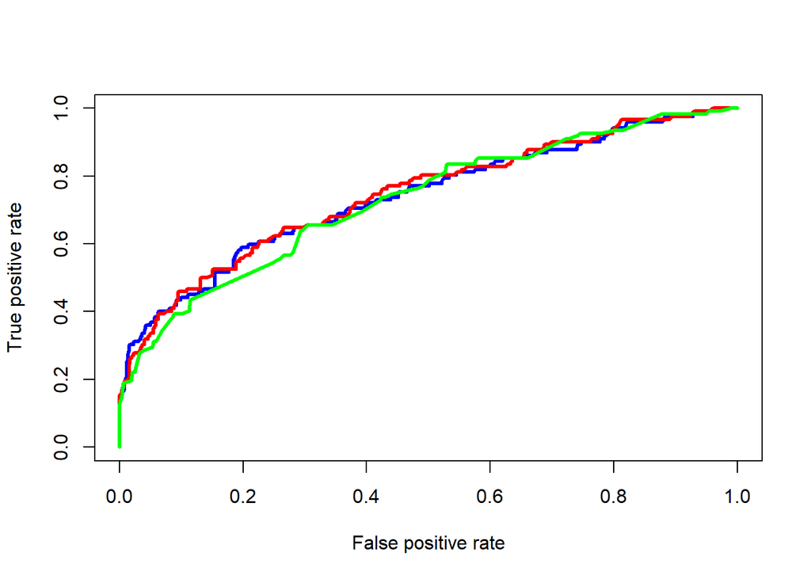

```r
pred1 <- prediction(p, test$delay, c("ontime","delayed"))
perf1 <- performance(pred1, measure= "tpr", x.measure="fpr")

pred2 <- prediction(prob_step, test$delay, c("ontime","delayed"))
perf2 <- performance(pred2, measure= "tpr", x.measure="fpr")

pred3 <- prediction(pred_prob, test$delay, c("ontime","delayed"))
perf3 <- performance(pred3, measure= "tpr", x.measure="fpr")

plot(perf1, col="blue", lwd=3)
plot(perf2, col="red", lwd=3, add=TRUE)
plot(perf3, col="green", lwd=3, add=TRUE)
```

```r
#compute AUC
auc <- performance(pred1, measure = "auc")
auc@y.values
```

```
## [[1]]
## [1] 0.7388681
```

```r
auc2 <- performance(pred2, measure = "auc")
auc2@y.values
```

```
## [[1]]
## [1] 0.7445355
```

```r
auc3 <- performance(pred3, measure = "auc")
auc3@y.values
```

```
## [[1]]
## [1] 0.7284153
```

#### 8번 모델이 가장 작은 AUC값을 가지고 7번 모델이 가장 큰 AUC값을 가진다. 하지만 3개의 모델의 AUC값이 차이가 유의미하게 난다고 볼 수 없으므로 3개의 모델 모두 비슷한 성능을 가진다고 볼 수 있다.

| Model | AUC |
| --- | --- |
| 6번 모델 | 0.7388681 |
| 7번 모델 | 0.7445355 |
| 8번 모델 | 0.7284153 |

### 10. Training set을 대상으로 k-nn을 적용해보자. 이때 train() 함수를 사용한 cross validation으로 Accuracy가 가장 높은 best 값을 찾는다.

```r
#knn model
set.seed(12)
knn_model <- train(delay~., data=train, method="knn", trControl=trainControl(method="repeatedcv", number=10, repeats=5), tuneGrid = expand.grid(k=1:31))
knn_model$results
```

```
##     k  Accuracy         Kappa  AccuracySD     KappaSD
## 1   1 0.7742023  0.1544514381 0.030657982 0.103634640
## 2   2 0.7832074  0.1364950873 0.020208842 0.079748482
## 3   3 0.8063533  0.1357326262 0.016799554 0.085096486
## 4   4 0.8142786  0.1315507674 0.013167630 0.069093603
## 5   5 0.8181206  0.1198078330 0.012698969 0.076041647
## 6   6 0.8177276  0.1062085560 0.012273807 0.067435943
## 7   7 0.8154759  0.0792019857 0.010523309 0.062874297
## 8   8 0.8164048  0.0754165692 0.009971060 0.065399778
## 9   9 0.8165312  0.0666173547 0.008878210 0.061048181
## 10 10 0.8162698  0.0632258746 0.009160853 0.058518105
## 11 11 0.8152136  0.0541355243 0.008312961 0.052757295
## 12 12 0.8138926  0.0458105725 0.007187680 0.047756128
## 13 13 0.8142865  0.0444875210 0.007242163 0.044151230
## 14 14 0.8137567  0.0401089783 0.006552703 0.041790505
```

[output cut: 17 more lines]

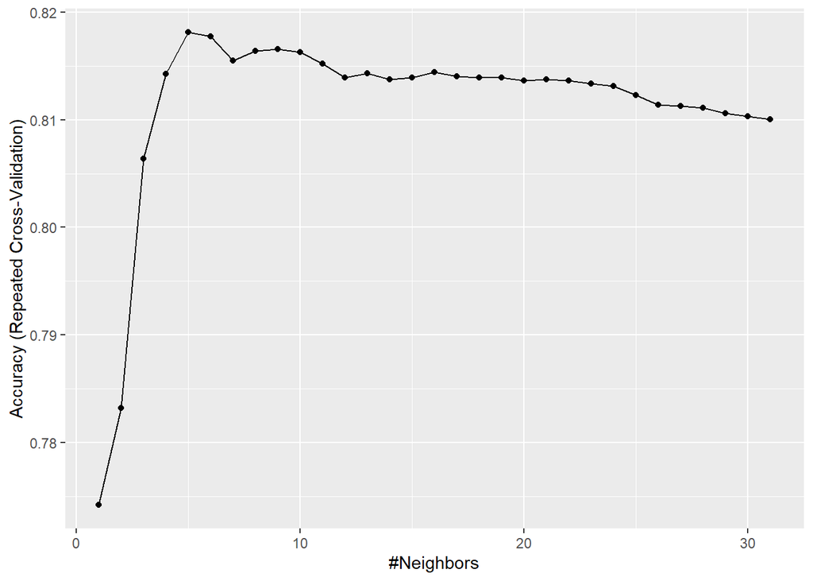

```r
#knn그래프
ggplot(knn_model)
```

```r
knn_model$bestTune
```

```
##   k
## 5 5
```

```r
#test set에 대한 confusion matrix
test_pred_2 <- predict(knn_model, test)
confusionMatrix(test_pred_2,test$delay,positive="delayed")
```

```
## Confusion Matrix and Statistics
##
##           Reference
## Prediction ontime delayed
##    ontime     516     101
##    delayed      9      21
##
##                Accuracy : 0.83
##                  95% CI : (0.7988, 0.8581)
##     No Information Rate : 0.8114
##     P-Value [Acc > NIR] : 0.1231
##
##                   Kappa : 0.2181
##
##  Mcnemar's Test P-Value : <2e-16
##
##             Sensitivity : 0.17213
##             Specificity : 0.98286
##          Pos Pred Value : 0.70000
##          Neg Pred Value : 0.83630
##              Prevalence : 0.18856
##          Detection Rate : 0.03246
##    Detection Prevalence : 0.04637
##       Balanced Accuracy : 0.57749
##
##        'Positive' Class : delayed
##
```

#### 10-1. best k값은 5이다.

#### 10-2. Accuracy:0.83, Sensitivity: 0.17213, Specificity: 0.98286이다. ontime으로 예측한 것 중 실제 ontime인 것은 516개, 실제 delayed인 것은 101개이며 delayed로 예측한 것 중 실제 ontime인 것은 9개, 실제 delayed인 것은 21개이다.

| Model | Accuracy | Sensitivity | Specificity |
| --- | --- | --- | --- |
| knn model | 0.83 | 0.17213 | 0.98286 |
| Threshold(k=0.2) | 0.7094 | 0.6311 | 0.7276 |
| Threshold(k=0.3) | 0.7867 | 0.4672 | 0.8610 |
| Threshold(k=0.5) | 0.8485 | 0.24590 | 0.98857 |
| Threshold(k=0.7) | 0.8377 | 0.13934 | 1.00000 |
| lasso model | 0.8377 | 0.15574 | 0.99619 |

## 2. OJ Dataset

### SLR 패키지에 속해 있는 OJ 데이터셋은 Citrus Hill과 Minute Maid Orange Juice를 구매한 1,070명의 고객에 대한 정보를 포함한다. 고객 및 제품 정보를 담고 있는 17개의 feature를 사용하여 고객이 두 제품 중 어떤 것을 구매할지(Purchase 변수) 예측하는 모델을 SVM을 활용하여 만들어본다. Linear, RBF, Polynomial Kernel을 사용한 SVM 모델을 만들어보고 성능을 비교해보자. 어떤 SVM 모델이 가장 좋은 성능을 보이는가?

```r
library(ISLR)
str(OJ)
```

```
## 'data.frame':    1070 obs. of  18 variables:
##  $ Purchase      : Factor w/ 2 levels "CH","MM": 1 1 1 2 1 1 1 1 1 1 ...
##  $ WeekofPurchase: num  237 239 245 227 228 230 232 234 235 238 ...
##  $ StoreID       : num  1 1 1 1 7 7 7 7 7 7 ...
##  $ PriceCH       : num  1.75 1.75 1.86 1.69 1.69 1.69 1.69 1.75 1.75 1.75 ...
##  $ PriceMM       : num  1.99 1.99 2.09 1.69 1.69 1.99 1.99 1.99 1.99 1.99 ...
##  $ DiscCH        : num  0 0 0.17 0 0 0 0 0 0 0 ...
##  $ DiscMM        : num  0 0.3 0 0 0 0 0.4 0.4 0.4 0.4 ...
##  $ SpecialCH     : num  0 0 0 0 0 0 1 1 0 0 ...
##  $ SpecialMM     : num  0 1 0 0 0 1 1 0 0 0 ...
##  $ LoyalCH       : num  0.5 0.6 0.68 0.4 0.957 ...
##  $ SalePriceMM   : num  1.99 1.69 2.09 1.69 1.69 1.99 1.59 1.59 1.59 1.59 ...
##  $ SalePriceCH   : num  1.75 1.75 1.69 1.69 1.69 1.69 1.69 1.75 1.75 1.75 ...
##  $ PriceDiff     : num  0.24 -0.06 0.4 0 0 0.3 -0.1 -0.16 -0.16 -0.16 ...
##  $ Store7        : Factor w/ 2 levels "No","Yes": 1 1 1 1 2 2 2 2 2 2 ...
##  $ PctDiscMM     : num  0 0.151 0 0 0 ...
##  $ PctDiscCH     : num  0 0 0.0914 0 0 ...
##  $ ListPriceDiff : num  0.24 0.24 0.23 0 0 0.3 0.3 0.24 0.24 0.24 ...
##  $ STORE         : num  1 1 1 1 0 0 0 0 0 0 ...
```

```r
#missing value 제거
oj <- na.omit(OJ)
str(oj)
```

```
## 'data.frame':    1070 obs. of  18 variables:
##  $ Purchase      : Factor w/ 2 levels "CH","MM": 1 1 1 2 1 1 1 1 1 1 ...
##  $ WeekofPurchase: num  237 239 245 227 228 230 232 234 235 238 ...
##  $ StoreID       : num  1 1 1 1 7 7 7 7 7 7 ...
##  $ PriceCH       : num  1.75 1.75 1.86 1.69 1.69 1.69 1.69 1.75 1.75 1.75 ...
##  $ PriceMM       : num  1.99 1.99 2.09 1.69 1.69 1.99 1.99 1.99 1.99 1.99 ...
##  $ DiscCH        : num  0 0 0.17 0 0 0 0 0 0 0 ...
##  $ DiscMM        : num  0 0.3 0 0 0 0 0.4 0.4 0.4 0.4 ...
##  $ SpecialCH     : num  0 0 0 0 0 0 1 1 0 0 ...
##  $ SpecialMM     : num  0 1 0 0 0 1 1 0 0 0 ...
##  $ LoyalCH       : num  0.5 0.6 0.68 0.4 0.957 ...
##  $ SalePriceMM   : num  1.99 1.69 2.09 1.69 1.69 1.99 1.59 1.59 1.59 1.59 ...
##  $ SalePriceCH   : num  1.75 1.75 1.69 1.69 1.69 1.69 1.69 1.75 1.75 1.75 ...
##  $ PriceDiff     : num  0.24 -0.06 0.4 0 0 0.3 -0.1 -0.16 -0.16 -0.16 ...
##  $ Store7        : Factor w/ 2 levels "No","Yes": 1 1 1 1 2 2 2 2 2 2 ...
##  $ PctDiscMM     : num  0 0.151 0 0 0 ...
##  $ PctDiscCH     : num  0 0 0.0914 0 0 ...
##  $ ListPriceDiff : num  0.24 0.24 0.23 0 0 0.3 0.3 0.24 0.24 0.24 ...
##  $ STORE         : num  1 1 1 1 0 0 0 0 0 0 ...
```

```r
#taining, test set 나누기
set.seed(123)
library(rsample)
split <- initial_split(oj, prop=0.5, strata = "Purchase")
oj_train <- training(split)
oj_test <- testing(split)


library(e1071)
#Linear kernel svm
set.seed(123)
l_tune.out <- tune(svm, Purchase~., data=oj_train, kernel = "linear", ranges = list(cost=10^seq(-3,3)))

summary(l_tune.out)
```

```
##
## Parameter tuning of 'svm':
##
## - sampling method: 10-fold cross validation
##
## - best parameters:
##  cost
##  0.01
##
## - best performance: 0.1643955
##
## - Detailed performance results:
##    cost     error dispersion
## 1 1e-03 0.3770440 0.07120427
## 2 1e-02 0.1643955 0.04031171
## 3 1e-01 0.1680992 0.04822828
## 4 1e+00 0.1736897 0.04579913
## 5 1e+01 0.1680992 0.05426176
## 6 1e+02 0.1718379 0.05417053
## 7 1e+03 0.1718379 0.04879212
```

```r
l_tune.out$best.parameters
```

```
##   cost
## 2 0.01
```

```r
linear_bestmodel <- l_tune.out$best.model

linear_pred <- predict(linear_bestmodel, oj_test)
confusionMatrix(linear_pred, oj_test$Purchase)
```

```
## Confusion Matrix and Statistics
##
##           Reference
## Prediction  CH  MM
##         CH 292  57
##         MM  34 151
##
##                Accuracy : 0.8296
##                  95% CI : (0.795, 0.8605)
##     No Information Rate : 0.6105
##     P-Value [Acc > NIR] : <2e-16
##
##                   Kappa : 0.6344
##
##  Mcnemar's Test P-Value : 0.0211
##
##             Sensitivity : 0.8957
##             Specificity : 0.7260
##          Pos Pred Value : 0.8367
##          Neg Pred Value : 0.8162
##              Prevalence : 0.6105
##          Detection Rate : 0.5468
##    Detection Prevalence : 0.6536
##       Balanced Accuracy : 0.8108
##
##        'Positive' Class : CH
##
```

```r
#RBF kernel svm
set.seed(123)
r_tune <- tune(svm, Purchase~., data=oj_train, kernel="radial", range=list(cost=c(0.01,0.1,1,10,100,1000),gamma=c(0.01,0.1,1,10,100)))

summary(r_tune)
```

```
##
## Parameter tuning of 'svm':
##
## - sampling method: 10-fold cross validation
##
## - best parameters:
##  cost gamma
##    10  0.01
##
## - best performance: 0.1716282
##
## - Detailed performance results:
##     cost gamma     error dispersion
## 1  1e-02 1e-02 0.3900419 0.06680045
## 2  1e-01 1e-02 0.3249126 0.08230890
```

[output cut: 28 more lines]

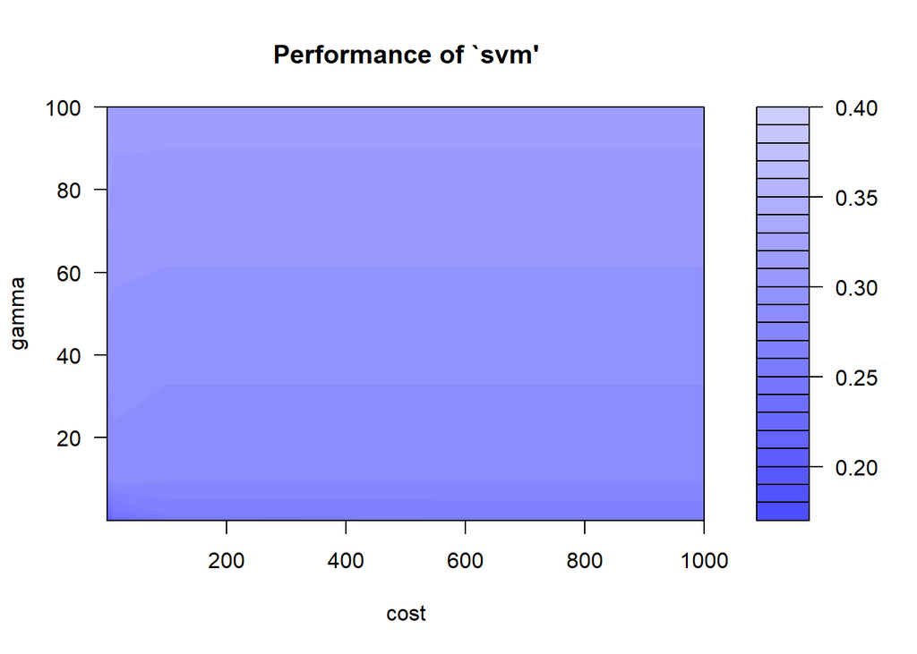

```r
#tuning 결과 시각화
plot(r_tune)
```

```r
rbf_pred <- predict(r_tune$best.model,oj_test)
confusionMatrix(rbf_pred, oj_test$Purchase)
```

```
## Confusion Matrix and Statistics
##
##           Reference
## Prediction  CH  MM
##         CH 286  56
##         MM  40 152
##
##                Accuracy : 0.8202
##                  95% CI : (0.785, 0.8519)
##     No Information Rate : 0.6105
##     P-Value [Acc > NIR] : <2e-16
##
##                   Kappa : 0.6167
##
##  Mcnemar's Test P-Value : 0.1258
##
##             Sensitivity : 0.8773
##             Specificity : 0.7308
##          Pos Pred Value : 0.8363
##          Neg Pred Value : 0.7917
##              Prevalence : 0.6105
##          Detection Rate : 0.5356
##    Detection Prevalence : 0.6404
##       Balanced Accuracy : 0.8040
##
##        'Positive' Class : CH
##
```

```r
#Polynomial kernel svm
set.seed(123)
p_tune.out <- tune(svm, Purchase~.,data=oj_train, kernel="polynomial", ranges=list(cost=c(0.01,0.1,1,10,100), degree=c(2,3,4)))

summary(p_tune.out)
```

```
##
## Parameter tuning of 'svm':
##
## - sampling method: 10-fold cross validation
##
## - best parameters:
##  cost degree
##   100      2
##
## - best performance: 0.1808875
##
## - Detailed performance results:
##     cost degree     error dispersion
## 1  1e-02      2 0.3900419 0.06680045
## 2  1e-01      2 0.3322152 0.03527013
## 3  1e+00      2 0.2090496 0.03338775
## 4  1e+01      2 0.1977638 0.03419025
## 5  1e+02      2 0.1808875 0.04609072
## 6  1e-02      3 0.3564990 0.04315382
## 7  1e-01      3 0.3229560 0.04297427
## 8  1e+00      3 0.2183788 0.02582455
## 9  1e+01      3 0.1995807 0.03494906
## 10 1e+02      3 0.2276380 0.03831881
## 11 1e-02      4 0.3564990 0.04315382
## 12 1e-01      4 0.3378407 0.03517718
## 13 1e+00      4 0.2540182 0.05090360
## 14 1e+01      4 0.2238295 0.02087436
## 15 1e+02      4 0.2276730 0.04348797
```

```r
poly_pred <- predict(p_tune.out$best.model, oj_test)
confusionMatrix(poly_pred, oj_test$Purchase)
```

```
## Confusion Matrix and Statistics
##
##           Reference
## Prediction  CH  MM
##         CH 273  53
##         MM  53 155
##
##                Accuracy : 0.8015
##                  95% CI : (0.7651, 0.8345)
##     No Information Rate : 0.6105
##     P-Value [Acc > NIR] : <2e-16
##
##                   Kappa : 0.5826
##
##  Mcnemar's Test P-Value : 1
##
##             Sensitivity : 0.8374
##             Specificity : 0.7452
##          Pos Pred Value : 0.8374
##          Neg Pred Value : 0.7452
##              Prevalence : 0.6105
##          Detection Rate : 0.5112
##    Detection Prevalence : 0.6105
##       Balanced Accuracy : 0.7913
##
##        'Positive' Class : CH
##
```

#### Accuracy가 Linear kernel svm이 가장 높고 Polynomial kernel svm이 가장 낮은 것을 볼 수 있다. 하지만 세 개의 모델 모두 Accuracy의 차이가 유의미하다고 볼 수 없을 정도로 큰 차이를 보이지는 않으므로 비슷한 성능을 가진다고 볼 수 있다.

| Model | Accuracy | Sensitivity | Specificity |
| --- | --- | --- | --- |
| Linear kernel svm | 0.8296 | 0.8957 | 0.7260 |
| RBF kernel svm | 0.8202 | 0.8773 | 0.7308 |
| Polynomial kernel svm | 0.8015 | 0.8374 | 0.7452 |